# TakeHome 4

Author

Matt Maslow

```r
library(tidyverse)
library(broom)
heart_df <- read_csv(here::here("data/heart.csv")) |>
  mutate(target = case_when(target == 1 ~ 0,
                            target == 0 ~ 1)) ## flip coding of response
heart_df
```

```
# A tibble: 303 × 14
     age   sex    cp trestbps  chol   fbs restecg thalach exang oldpeak slope
   <dbl> <dbl> <dbl>    <dbl> <dbl> <dbl>   <dbl>   <dbl> <dbl>   <dbl> <dbl>
 1    63     1     3      145   233     1       0     150     0     2.3     0
 2    37     1     2      130   250     0       1     187     0     3.5     0
 3    41     0     1      130   204     0       0     172     0     1.4     2
 4    56     1     1      120   236     0       1     178     0     0.8     2
 5    57     0     0      120   354     0       1     163     1     0.6     2
 6    57     1     0      140   192     0       1     148     0     0.4     1
 7    56     0     1      140   294     0       0     153     0     1.3     1
 8    44     1     1      120   263     0       1     173     0     0       2
 9    52     1     2      172   199     1       1     162     0     0.5     2
10    57     1     2      150   168     0       1     174     0     1.6     2
# ℹ 293 more rows
# ℹ 3 more variables: ca <dbl>, thal <dbl>, target <dbl>
```

# Question 1 (1 point).

*Fit a model with target as the response and age, sex, and chol as the predictors. Tidy the model; then, interpret the fitted regression coefficient for age in context of the problem.*

```r
mod1 <- glm(target ~ age + sex + chol, data = heart_df)
mod1 %>% tidy()
```

```
# A tibble: 4 × 5
  term         estimate std.error statistic       p.value
  <chr>           <dbl>     <dbl>     <dbl>         <dbl>
1 (Intercept) -0.721     0.201        -3.59 0.000382
2 age          0.0130    0.00300       4.33 0.0000207
3 sex          0.347     0.0582        5.95 0.00000000745
4 chol         0.000951  0.000533      1.78 0.0755
```

```r
mod1 %>% coef() %>% exp()
```

```
(Intercept)         age         sex        chol
  0.4863316   1.0130573   1.4141873   1.0009518
```

# Question 2 (1 point).

*Fit a model with target as the response and age, sex, chol, the interaction between age and sex, the interaction between age and chol, and the interaction between sex and chol as predictors. Glance at the model from Question 1 and the model from this question. Which is the better model, according to the BIC criterion?*

```r
mod2 <- glm(target ~ age + sex + chol + age:sex + age:chol + sex:chol, data = heart_df)
mod1 %>% glance()
```

```
# A tibble: 1 × 8
  null.deviance df.null logLik   AIC   BIC deviance df.residual  nobs
          <dbl>   <int>  <dbl> <dbl> <dbl>    <dbl>       <int> <int>
1          75.1     302  -194.  397.  416.     63.7         299   303
```

```r
mod2 %>% glance()
```

```
# A tibble: 1 × 8
  null.deviance df.null logLik   AIC   BIC deviance df.residual  nobs
          <dbl>   <int>  <dbl> <dbl> <dbl>    <dbl>       <int> <int>
1          75.1     302  -192.  400.  430.     63.1         296   303
```

# Question 3 (1 point).

*Sketch a visualization that helps interpret the fitted model from Question 1, using “predicted probability” of heart disease as the y-axis in your visualization. You do not need to turn anything in for this question, but it is suggested that you practice sketching for the handwritten quiz.*

On paper

# Question 4 (5 points).

*Using the strategy outlined in class, construct a visualization that helps interpret the fitted model from Question 1, using “predicted probability” of heart disease as the y-axis in your visualization.*

```r
# getting the data ready fo question 5
library(modelr)
grid <-heart_df %>% data_grid(
  sex = c(1, 0),
  age = seq_range(heart_df$age, n = 5),
  chol = seq_range(heart_df$chol, n = 5)
)
aug_heart <- augment(mod1, newdata = grid, se_fit = TRUE, interval = "prediction")
aug_heart
```

```
# A tibble: 50 × 5
     sex   age  chol .fitted .se.fit
   <dbl> <dbl> <dbl>   <dbl>   <dbl>
 1     0    29  126  -0.225   0.107
 2     0    29  236. -0.121   0.0915
 3     0    29  345  -0.0165  0.110
 4     0    29  454.  0.0877  0.150
 5     0    29  564   0.192   0.200
 6     0    41  126  -0.0691  0.0900
 7     0    41  236.  0.0351  0.0641
 8     0    41  345   0.139   0.0832
 9     0    41  454.  0.243   0.129
10     0    41  564   0.348   0.182
# ℹ 40 more rows
```

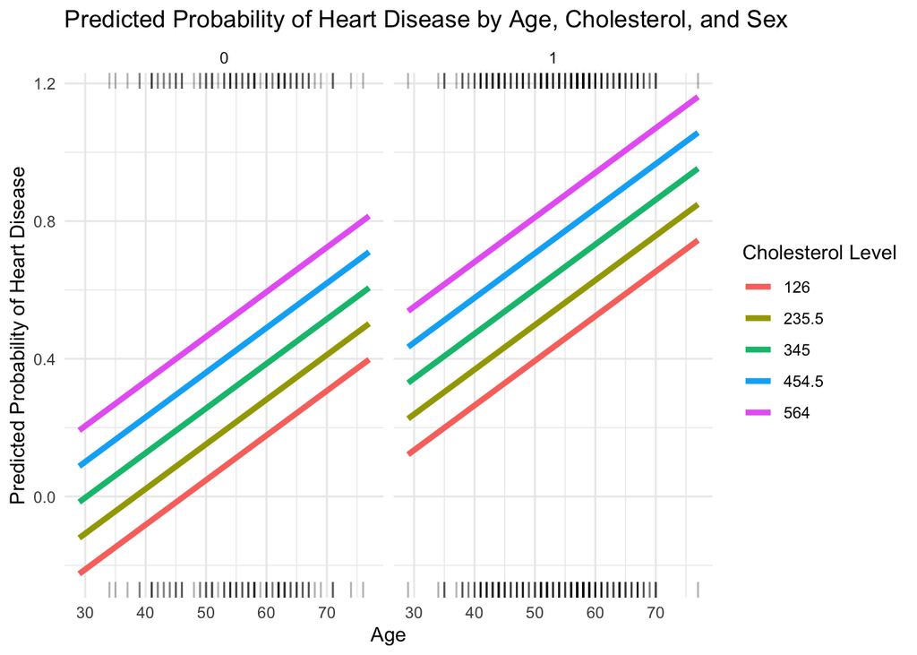

```r
aug_heart %>%
  ggplot(aes(x = age, y = .fitted)) +
  geom_line(aes(color = as.factor(chol)), size=1.5) +
  geom_rug(data = heart_df, sides = "t", alpha = 0.3,
           aes(y = target)) +
  geom_rug(data = heart_df, sides = "b", alpha = 0.3,
           aes(y = target)) +
  facet_wrap(~sex) +
  theme_minimal() +
  labs(title = "Predicted Probability of Heart Disease by Age, Cholesterol, and Sex",
       x = "Age",
       y = "Predicted Probability of Heart Disease",
       color = "Cholesterol Level")
```

# Question 5 (1 point).

*We constructed the previous models and the previous plot with limited information about who the people are that make up the observations in this data set. Thinking more about the context of this data and about a “population” that these patients might represent, what else would you want to know about the people in this data set?*

I would want to know more about the lifestyle of the patients in this data set. For example, I would want to know if they smoke, how much they exercise, and what their diet is like. I would also want to know if they have any family history of heart disease, and if they have any other health conditions.

# Question 6 (1 point).

*Suppose that we have a different data set on heart disease, with a quantitative measurement of “blockage” as the response variable. We give a particular treatment to a subset of patients in the study and measure the “blockage” before treatment and gain 6 weeks after treatment. Why is making a set of side-by-side boxplots with “pre vs. post” treatment on the x-axis and “blockage” on the y-axis not the best visual for this hypothetical data set?*

A set of side-by-side box plots would not be the best visual for this hypothetical data set because the data is paired. That is, the pre-treatment and post-treatment measurements are from the same patients. A better visual would be a set of side-by-side box plots with the difference in blockage before and after treatment on the y-axis, and the treatment group on the x-axis. This would allow us to see if the treatment had an effect on the blockage of the patients. Furthermore, could also, plot geom_lines one for each classification in order ot compare them on same plot, although plot the differences would show similar effect and is also a bit cleaner.